# Hands-on #1: raw data to OTU table

Verónica Lloréns-Rico, PhD

20/04/2021

In this tutorial we will follow the DADA2 pipeline to go from raw sequencing reads to an ASV table, as well as how to do the taxonomic assignation of sequences. This hands-on largely follows the official [DADA2 tutorial](https://benjjneb.github.io/dada2/tutorial.html), but with some changes for our own data.

# 1 Introduction

Short pptx presentation about the following topics:

- High-throughput 16S amplicon sequencing
- First preprocessing steps from the raw data: removal of primers, demultiplexing
- Differences between OTUs and ASVs
- Examples of pipelines to preprocess the data

# 2 From the *.fastq files to the ASV table: using the DADA2 pipeline

The data that we will use was originally generated for the following publication: “[Quantitative microbiome profiling links gut community variation to microbial load](https://www.nature.com/articles/nature24460)”.

To download the data, follow these steps:

1. Go to https://www.ebi.ac.uk/ena/browser/view/PRJEB21504
2. From the “Submitted FTP” column, select samples SC01 to SC20 (both R1 and R2 fastq files), you will need to go through the first 4 pages
3. Check that the option “Download files as zip” is active
4. Click on “Download selected files”
5. Move the “ena_files.zip” to the `data/` folder from the course and unzip.

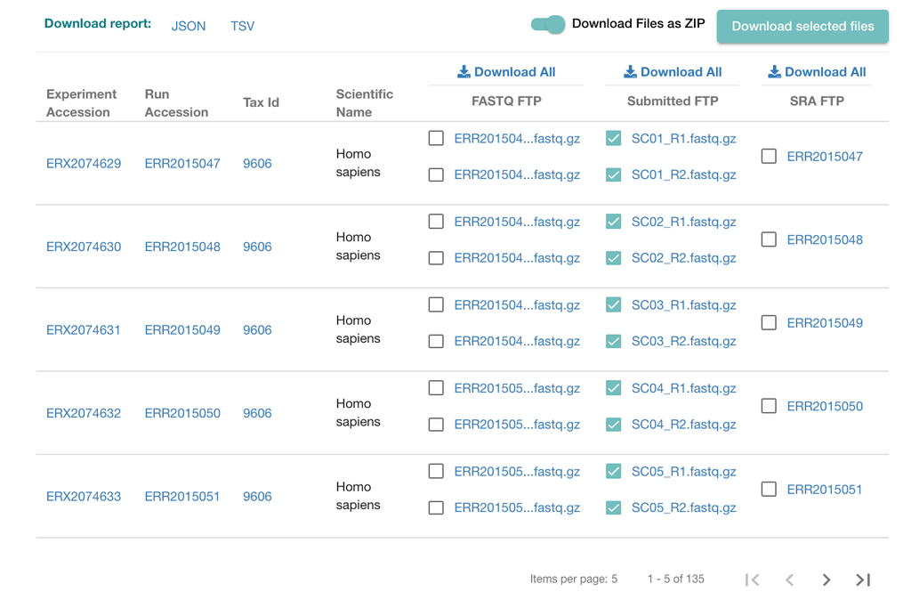

Before starting, **unzip the `ena_files.zip` file located in the `data/` folder**

## 2.1 Check that the files can be located properly

```r
# When working with your own data, change the path to the directory containing your demultiplexed R1 and R2 fastq files
path <- "data/"
fastqseqs <- list.files(path, pattern = ".fastq.gz") # take only fastq files, ignore the other files
fastqseqs
```

```
##  [1] "SC01_R1.fastq.gz" "SC01_R2.fastq.gz" "SC02_R1.fastq.gz" "SC02_R2.fastq.gz"
##  [5] "SC03_R1.fastq.gz" "SC03_R2.fastq.gz" "SC04_R1.fastq.gz" "SC04_R2.fastq.gz"
##  [9] "SC05_R1.fastq.gz" "SC05_R2.fastq.gz" "SC06_R1.fastq.gz" "SC06_R2.fastq.gz"
## [13] "SC07_R1.fastq.gz" "SC07_R2.fastq.gz" "SC08_R1.fastq.gz" "SC08_R2.fastq.gz"
## [17] "SC09_R1.fastq.gz" "SC09_R2.fastq.gz" "SC10_R1.fastq.gz" "SC10_R2.fastq.gz"
## [21] "SC11_R1.fastq.gz" "SC11_R2.fastq.gz" "SC12_R1.fastq.gz" "SC12_R2.fastq.gz"
## [25] "SC13_R1.fastq.gz" "SC13_R2.fastq.gz" "SC14_R1.fastq.gz" "SC14_R2.fastq.gz"
## [29] "SC15_R1.fastq.gz" "SC15_R2.fastq.gz" "SC16_R1.fastq.gz" "SC16_R2.fastq.gz"
## [33] "SC17_R1.fastq.gz" "SC17_R2.fastq.gz" "SC18_R1.fastq.gz" "SC18_R2.fastq.gz"
## [37] "SC19_R1.fastq.gz" "SC19_R2.fastq.gz" "SC20_R1.fastq.gz" "SC20_R2.fastq.gz"
```

```r
# You should see a list of 40 files in the output
fastqseqs <- sort(fastqseqs) # Sort ensures forward/reverse reads are in same order (they should already be)
```

## 2.2 Separate forward (R1) from reverse (R2) files and select sample names

```r
# Make sure that R1 is for forward read and R2 for reverse!
# In some sequencing protocols, the reads are reversed.
fnFs <- fastqseqs[grepl(".R1.fastq.gz", fastqseqs)] # Just select forward read files
fnRs <- fastqseqs[grepl(".R2.fastq.gz", fastqseqs)] # Just select reverse read files

# Get sample names from the first part of the forward read filenames
sample.names <- sapply(strsplit(fnFs, ".R1.fastq.gz"), `[`, 1) ## check if is 1 or 2!

# For the processing, get the full path to the files, not just the file names
fnFs <- file.path(path, fnFs)
fnRs <- file.path(path, fnRs)
```

## 2.3 Inspect read quality profiles

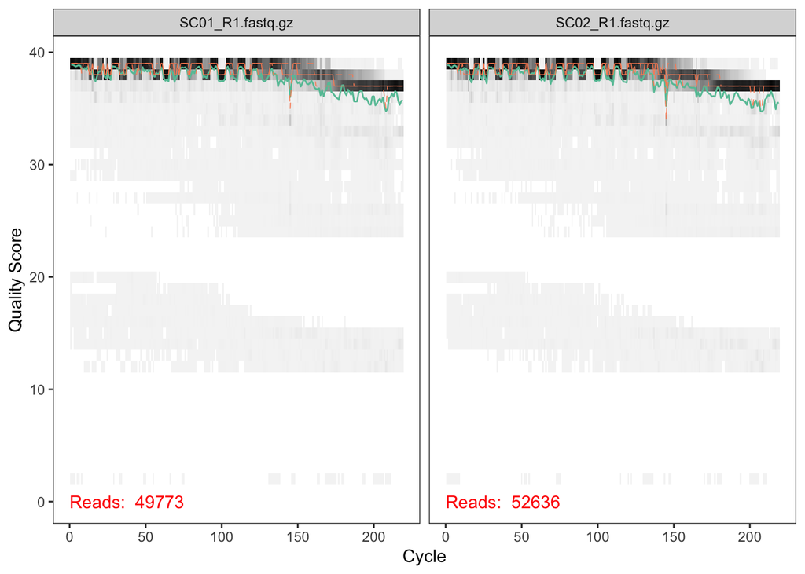

```r
plotQualityProfile(fnFs[1:2])
```

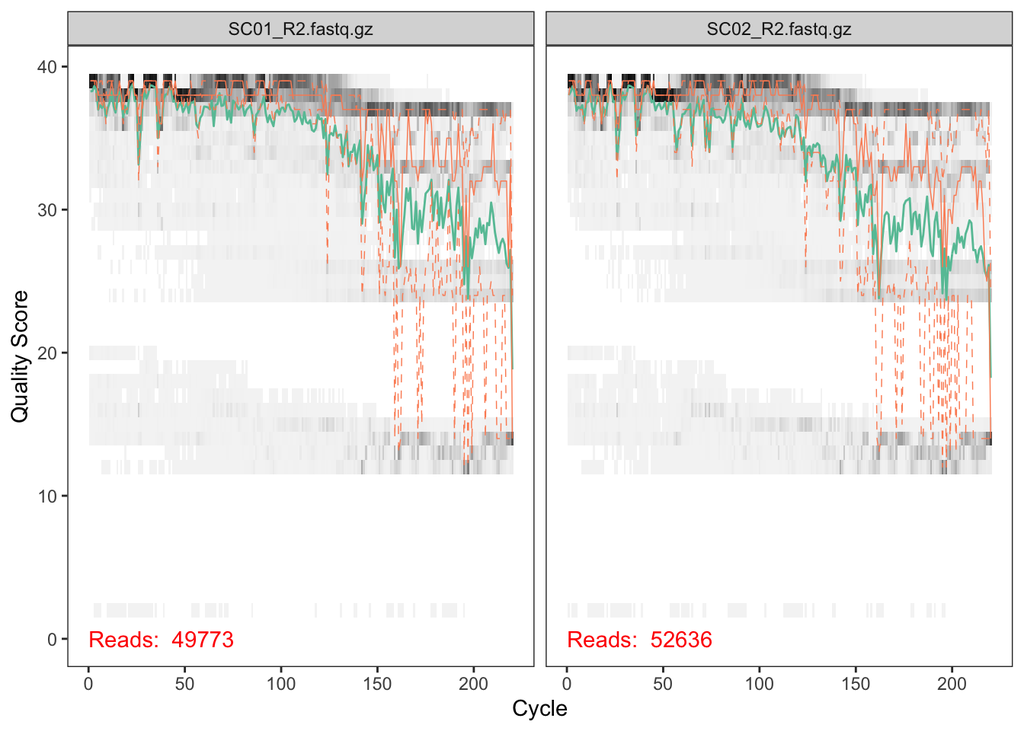

```r
plotQualityProfile(fnRs[1:2])
```

The quality of the reverse read decays after ~130 bases, so we will trim it. This is normal for Illumina, so there’s nothing to worry about.

## 2.4 Filter and trim sequences

In some cases, the primers and other technical sequences are removed during the demultiplexing. In our experiment, this was not the case, so we will trim them together with the bad quality bases: we will remove the first 30 bases of both R1 and R2 to make sure we remove these sequences.

If in your data, the primers were removed during demultiplexing, there is no need to trim additional bases now.

The parameters indicated below match with the ones used in the original publication, but will largely depend on your data, and you will have to chose them based on the quality profiles

```r
# Place filtered files in filtered/ subdirectory in the data folder
filt_path <- file.path(path, "filtered")

# Create names for the filtered files
filtFs <- file.path(filt_path, paste0(sample.names, "_F_filt.fastq.gz"))
filtRs <- file.path(filt_path, paste0(sample.names, "_R_filt.fastq.gz"))

# Filter - this takes ~2 min in a Macbook from 2015
out <- filterAndTrim(fnFs, # original forward files
                     filtFs, # filtered forward files
                     fnRs, # original reverse files
                     filtRs, # filtered reverse files
                     truncLen=c(200,140), # these settings are good for MiSeq (for our primer constructs)
                     trimLeft=c(30, 30), # trim the first bases (if low quality or if primers have not been removed)
                     maxN=0, # discard sequences with >0 Ns after truncation
                     maxEE=c(2,2), # discard reads with more than 2 Expected Errors (calculated from the quality score)
                     truncQ=11, # truncate reads when quality decreases below 11
                     rm.phix=TRUE, # removes traces of PhiX phage, used as internal control for sequencing
                     compress=TRUE, # compress the output
                     multithread=TRUE) # change to F if your computer does not have several cores you can use
head(out)
```

```
##                  reads.in reads.out
## SC01_R1.fastq.gz    49773     49114
## SC02_R1.fastq.gz    52636     51959
## SC03_R1.fastq.gz    54111     53525
## SC04_R1.fastq.gz    30300     27386
## SC05_R1.fastq.gz    51502     50838
## SC06_R1.fastq.gz    62627     62020
```

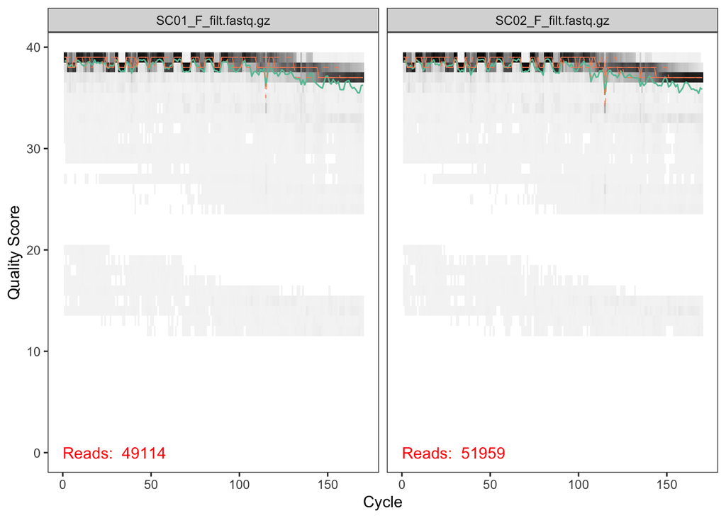

```r
# After filtering, we can check the quality of the filtered files to verify that we have solved the issues
plotQualityProfile(filtFs[1:2])
```

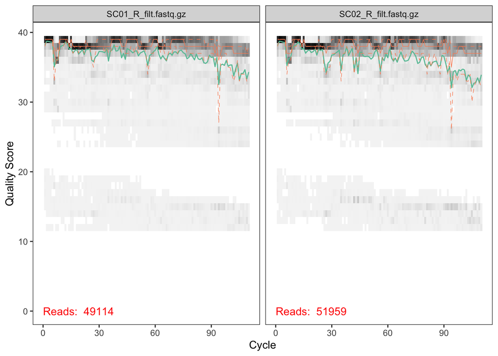

```r
plotQualityProfile(filtRs[1:2])
```

Now we see that we effectively removed the low quality bases, especially in the reverse reads.

## 2.5 Learn error rates

After the quality control of our data, the DADA2 pipeline requires the estimation of the error rates of this sequencing data. DADA2 will estimate what is the frequency of errors in our sequencing data, for instance of changing an “A” for a “G”. This frequency will depend on the quality score, as we expect that with higher quality scores, there will be less chances of error.

Therefore, in the next step we will estimate error rates for both forward and reverse reads

**NOTE:** for speed reasons, the argument `nbases` for the `learnErrors` function is quite low in this tutorial, for real cases, it’s better use the default (1e8)

```r
# With nbases = 1e7; this takes ~2min to run in a Macbook from 2015
set.seed(12345)
# Learn forward error rates
errF <- learnErrors(filtFs, nbases=1e7, multithread=TRUE)
```

```
## 17182410 total bases in 101073 reads from 2 samples will be used for learning the error rates.
```

```r
# Learn reverse error rates
errR <- learnErrors(filtRs, nbases=1e7,multithread=TRUE)
```

```
## 11118030 total bases in 101073 reads from 2 samples will be used for learning the error rates.
```

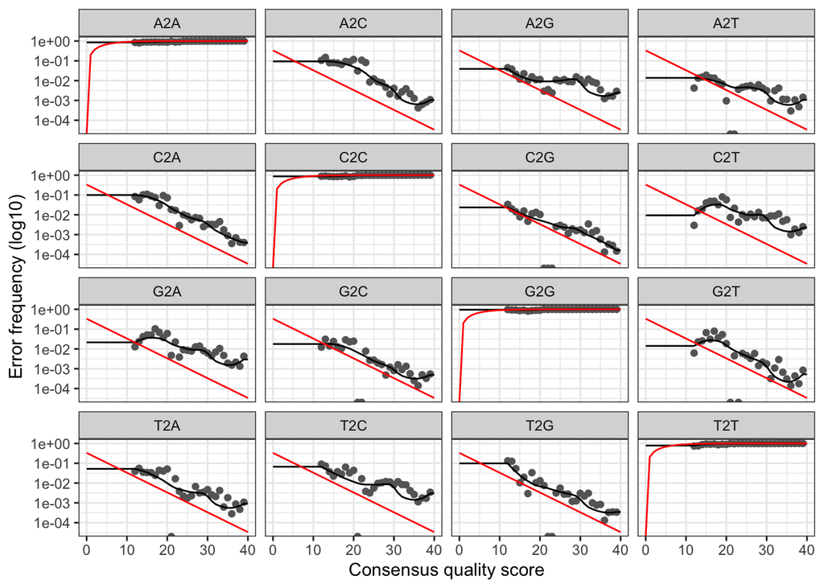

```r
# plot error rates
plotErrors(errF, nominalQ=TRUE)
```

## 2.6 Sample inference

After determining the error rates if the sequencers in our dataset, we are ready to implement the core function in the DADA2 denoising algorithm. The `dada` function uses the error estimates from the previous step to “predict” the original biological sequence that produced each read. This reduces a lot the number of different sequence variants in the dataset, as a single biological sequence can produce many different sequencing reads as a result of sequencing errors.

In previous DADA2 versions, there was a prior step of dereplication, i.e. collapse all the sequences that are identical to reduce computation time. As of v1.12, the dereplication step is included within the `dada` function, so it is not necessary to run it separately.

```r
# This part takes ~8 minutes in a macbook from 2015
dadaFs <- dada(filtFs, # the function will use the filtered files
               err=errF, # we pass on the calculated error rates
               multithread=TRUE # change if your computer does not allow multithreading
               )
```

```
## Sample 1 - 49114 reads in 9797 unique sequences.
## Sample 2 - 51959 reads in 8516 unique sequences.
## Sample 3 - 53525 reads in 15243 unique sequences.
## Sample 4 - 27386 reads in 15790 unique sequences.
## Sample 5 - 50838 reads in 12907 unique sequences.
## Sample 6 - 62020 reads in 12977 unique sequences.
## Sample 7 - 62627 reads in 12958 unique sequences.
## Sample 8 - 52704 reads in 13011 unique sequences.
## Sample 9 - 52826 reads in 12542 unique sequences.
## Sample 10 - 51073 reads in 7682 unique sequences.
## Sample 11 - 42735 reads in 10883 unique sequences.
## Sample 12 - 61165 reads in 15449 unique sequences.
## Sample 13 - 110040 reads in 28681 unique sequences.
## Sample 14 - 54452 reads in 11413 unique sequences.
## Sample 15 - 41170 reads in 10386 unique sequences.
## Sample 16 - 54942 reads in 8044 unique sequences.
## Sample 17 - 41375 reads in 8643 unique sequences.
## Sample 18 - 57147 reads in 14901 unique sequences.
## Sample 19 - 41205 reads in 12130 unique sequences.
## Sample 20 - 54684 reads in 17607 unique sequences.
```

```r
dadaRs <- dada(filtRs, # the function will use the filtered files
               err=errR, # we pass on the calculated error rates
               multithread=TRUE # change if your computer does not allow multithreading
               )
```

```
## Sample 1 - 49114 reads in 6611 unique sequences.
## Sample 2 - 51959 reads in 7272 unique sequences.
## Sample 3 - 53525 reads in 10049 unique sequences.
## Sample 4 - 27386 reads in 10647 unique sequences.
## Sample 5 - 50838 reads in 8188 unique sequences.
## Sample 6 - 62020 reads in 8903 unique sequences.
## Sample 7 - 62627 reads in 9662 unique sequences.
## Sample 8 - 52704 reads in 9674 unique sequences.
## Sample 9 - 52826 reads in 8616 unique sequences.
## Sample 10 - 51073 reads in 5865 unique sequences.
## Sample 11 - 42735 reads in 12259 unique sequences.
## Sample 12 - 61165 reads in 10399 unique sequences.
## Sample 13 - 110040 reads in 18327 unique sequences.
## Sample 14 - 54452 reads in 8508 unique sequences.
## Sample 15 - 41170 reads in 7319 unique sequences.
## Sample 16 - 54942 reads in 6576 unique sequences.
## Sample 17 - 41375 reads in 5700 unique sequences.
## Sample 18 - 57147 reads in 9837 unique sequences.
## Sample 19 - 41205 reads in 13263 unique sequences.
## Sample 20 - 54684 reads in 10585 unique sequences.
```

## 2.7 Merge forward and reverse reads

Before estimating taxonomy, we need to merge forward and reverse reads

```r
mergers <- mergePairs(dadaFs, filtFs, dadaRs, filtRs, verbose=TRUE)
```

```
## 45102 paired-reads (in 374 unique pairings) successfully merged out of 48262 (in 1477 pairings) input.
```

```
## 48790 paired-reads (in 332 unique pairings) successfully merged out of 51218 (in 1182 pairings) input.
```

```
## 48224 paired-reads (in 477 unique pairings) successfully merged out of 52212 (in 2029 pairings) input.
```

```
## 23582 paired-reads (in 208 unique pairings) successfully merged out of 26540 (in 1103 pairings) input.
```

```
## 47225 paired-reads (in 426 unique pairings) successfully merged out of 49863 (in 1458 pairings) input.
```

```
## 56649 paired-reads (in 371 unique pairings) successfully merged out of 61121 (in 1817 pairings) input.
```

```
## 59043 paired-reads (in 495 unique pairings) successfully merged out of 61489 (in 1552 pairings) input.
```

```
## 49257 paired-reads (in 441 unique pairings) successfully merged out of 51736 (in 1379 pairings) input.
```

```
## 49019 paired-reads (in 413 unique pairings) successfully merged out of 51780 (in 1456 pairings) input.
```

```
## 48724 paired-reads (in 267 unique pairings) successfully merged out of 50495 (in 938 pairings) input.
```

```
## 39540 paired-reads (in 269 unique pairings) successfully merged out of 41965 (in 1096 pairings) input.
```

```
## 55930 paired-reads (in 531 unique pairings) successfully merged out of 59947 (in 2054 pairings) input.
```

```
## 100314 paired-reads (in 857 unique pairings) successfully merged out of 107579 (in 3852 pairings) input.
```

```
## 51353 paired-reads (in 383 unique pairings) successfully merged out of 53414 (in 1083 pairings) input.
```

```
## 36887 paired-reads (in 340 unique pairings) successfully merged out of 40136 (in 1451 pairings) input.
```

```
## 52118 paired-reads (in 338 unique pairings) successfully merged out of 54386 (in 1107 pairings) input.
```

```
## 39495 paired-reads (in 355 unique pairings) successfully merged out of 40706 (in 832 pairings) input.
```

```
## 52197 paired-reads (in 496 unique pairings) successfully merged out of 55944 (in 1842 pairings) input.
```

```
## 37998 paired-reads (in 226 unique pairings) successfully merged out of 40597 (in 933 pairings) input.
```

```
## 49147 paired-reads (in 552 unique pairings) successfully merged out of 53169 (in 2041 pairings) input.
```

```r
# Inspect the merger data.frame from the first sample
names(mergers) <- sample.names
head(mergers[[1]])
```

|  | sequence | abundance | forward | reverse | nmatch | nmismatch | nindel | prefer | accept |
| --- | --- | --- | --- | --- | --- | --- | --- | --- | --- |
| 1 | GCGTCAGTTATCGTCCAGTAAGCCGCCTTCGCCACTGGTGTTCCTCCTAATATCTACGCATTTCACCGCTACACTAGGAATTCCGCTTACCCCTCCGACACTCTAGTACGACAGTTTCCAATGCAGTACCGGGGTTGAGCCCCGGGCTTTCACATCAGACTTGCCGCACCGCCTGCGCTCCCTTTACACCCAG | 5898 | 1 | 1 | 87 | 0 | 0 | 2 | TRUE |
| 2 | GCGTCAGTTGGTGCCCAGTAGGCCGCCTTCGCCACTGGTGTTCCTCCCGATATCTACGCATTCCACCGCTACACCGGGAATTCCGCCTACCTCTGCACTACTCAAGAAAAACAGTTTTGAAAGCAGTTCATGGGTTGAGCCCATGGATTTCACTTCCAACTTGTTCTCCCGCCTGCGCTCCCTTTACACCCAG | 4312 | 2 | 2 | 87 | 0 | 0 | 1 | TRUE |
| 3 | ATGTCAGTTGCAGCTTAGCAGGCTGCCTTCGCAATCGGAGTTCTTCGTGATATCTAAGCATTTCACCGCTACACCACGAATTCCGCCTGCCTCAACTGCACTCAAGATATCCAGTATCAACTGCAATTTTACGGTTGAGCCGCAAACTTTCACAACTGACTTAAACATCCATCTACGCTCCCTTTAAACCCAA | 3306 | 3 | 3 | 87 | 0 | 0 | 2 | TRUE |
| 4 | ATGTCAGTTGCAGCTTAGCAGGCTGCCTTCGCAATCGGAGTTCTTCGTGATATCTAAGCATTTCACCGCTACACCACGAATTCCGCCTGCCTCAACTGCACTCAAGACATCCAGTATCAACTGCAATTTTACGGTTGAGCCGCAAACTTTCACAACTGACTTAAACATCCATCTACGCTCCCTTTAAACCCAA | 3082 | 4 | 4 | 87 | 0 | 0 | 2 | TRUE |
| 5 | GTGTCAGTTATGGTTTAGTAAGCTGCCTTCGCAATCGGAGTTCTGCGTGATATCTATGCATTTCACCGCTACACCACGCATTCCGCCTACCTCAAACACACTCAAGTAACCCAGTTTCAACGGCAATTTTATGGTTGAGCCACAAACTTTCACCGCTGACTTAAATCACCACCTACGCACCCTTTAAACCCAA | 1676 | 5 | 5 | 87 | 0 | 0 | 2 | TRUE |
| 6 | ACGTCAGTCATCGTCCAGCAAGCCGCCTTCGCCACTGGTGTTCCTCCTAATATCTACGCATTTCACCGCTACACTAGGAATTCCACTTGCCTCTCCGACACTCTAGCTCAGCAGTTCCAAATGCAGTCCCGGGGTTGAGCCCCGGGCTTTCACATCTGGCTTGCCGTGCCGTCTACGCTCCCTTTACACCCAG | 1068 | 6 | 6 | 87 | 0 | 0 | 2 | TRUE |

## 2.8 Construct sequence (ASV) table and remove chimeras

After merging forward and reverse reads, we construct a table that contains the info on the frequencies of each ASV in each of the samples analyzed.

With this table, we can also remove chimeric reads. Chimeric sequences are identified if they can be exactly reconstructed by combining a left-segment and a right-segment from two more abundant “parent” sequences.

```r
seqtab <- makeSequenceTable(mergers)
dim(seqtab)
```

```
## [1]   20 3788
```

```r
# Inspect distribution of sequence lengths
table(nchar(getSequences(seqtab)))
```

```
##
##  170  192  193  194
##    3  368 3393   24
```

```r
# Remove chimeras
seqtab.nochim <- removeBimeraDenovo(seqtab, method="consensus", multithread=TRUE, verbose=TRUE)
```

```
## Identified 2672 bimeras out of 3788 input sequences.
```

```r
dim(seqtab.nochim)
```

```
## [1]   20 1116
```

```r
sum(seqtab.nochim)/sum(seqtab)
```

```
## [1] 0.8098807
```

About 80% of the reads remain after removing chimeras.

## 2.9 Last checks: track reads throughout the DADA2 pipeline

As a last quality check of the DADA2 pipeline, we can track how many reads were lost at each of the steps we performed.

```r
getN <- function(x) sum(getUniques(x))
track <- cbind(out, sapply(dadaFs, getN), sapply(dadaRs, getN), sapply(mergers, getN),rowSums(seqtab.nochim))
colnames(track) <- c("input", "filtered", "denoisedF", "denoisedR", "merged", "nonchim")
rownames(track) <- sample.names
head(track)
```

```
##      input filtered denoisedF denoisedR merged nonchim
## SC01 49773    49114     48437     48880  45102   33915
## SC02 52636    51959     51444     51708  48790   39203
## SC03 54111    53525     52524     53131  48224   36627
## SC04 30300    27386     26751     27082  23582   20970
## SC05 51502    50838     50076     50559  47225   39080
## SC06 62627    62020     61354     61749  56649   41174
```

We can see that there is no step that is causing a disproportionate reduction in the reads of the pipeline.

# 3 Assign taxonomy to the ASV table

After data cleaning and getting the denoised sequences, we can now assign the corresponding taxonomy. Different databases of taxonomic assignments of 16S sequences exist, here, we will use the RDP database.

```r
# this step takes ~5 min on a macbook from 2015
taxHS <- assignTaxonomy(seqtab.nochim, # the ASV table
                        refFasta = "data/rdp_train_set_16.fa.gz",
                        tryRC = T,
                        multithread=TRUE)
```

The assignation with the RDP database (release 16) gives a taxonomic classification up to the genus level. Since DADA2 attempts to elucidate the actual biological sequence producing the different sequencing reads, we can use this information to try to estimate taxonomy also at the species level.

```r
# Add species
taxHS <- addSpecies(taxHS, "data/rdp_species_assignment_16.fa.gz", tryRC = T)

colnames(taxHS) <- c("Kingdom", "Phylum", "Class", "Order", "Family", "Genus", "Species")

# show taxonomy
unname(head(taxHS))
```

```
##      [,1]       [,2]            [,3]          [,4]            [,5]
## [1,] "Bacteria" "Firmicutes"    "Clostridia"  "Clostridiales" "Ruminococcaceae"
## [2,] "Bacteria" "Firmicutes"    "Clostridia"  "Clostridiales" "Lachnospiraceae"
## [3,] "Bacteria" "Firmicutes"    "Clostridia"  "Clostridiales" "Ruminococcaceae"
## [4,] "Bacteria" "Firmicutes"    "Clostridia"  "Clostridiales" "Ruminococcaceae"
## [5,] "Bacteria" "Bacteroidetes" "Bacteroidia" "Bacteroidales" "Bacteroidaceae"
## [6,] "Bacteria" "Bacteroidetes" "Bacteroidia" "Bacteroidales" "Prevotellaceae"
##      [,6]               [,7]
## [1,] "Faecalibacterium" "prausnitzii"
## [2,] "Roseburia"        NA
## [3,] "Faecalibacterium" "prausnitzii"
## [4,] "Faecalibacterium" "prausnitzii"
## [5,] "Bacteroides"      NA
## [6,] "Prevotella"       NA
```

Now, we can write all the data generated to disk

```r
# Write to disk
dir.create("output")
write.table(track, file = "output/track_reads.tsv", quote=FALSE, )
write.table(seqtab.nochim, file = "output/sequence_table_SV.tsv", quote=FALSE)
write.table(taxHS, file = "output/taxonomy_SV.tsv", quote=FALSE)
```

# 4 Transfer data to phyloseq

In later tutorials in this course, we will manipulate and analyze data using different packages, one that is commonly used is phyloseq. So here, we will see how we can directly transfer the ASV abundances and taxonomic classification to phyloseq.

Phyloseq objects contain all the information about the 16S data, structured in 3 parts: - otu_table (the table containing the frequencies of all OTUs or, in our case, ASVs) - tax_table (the table with the taxonomic annotation) - sample_data (metadata of the samples)

Here, we don’t have sample metadata (such as patient BMI, sex or age), but we have the other two components, and we can build a phyloseq object with them:

```r
ps <- phyloseq(otu_table(seqtab.nochim, taxa_are_rows = F),
               tax_table(taxHS))

ps
```

```
## phyloseq-class experiment-level object
## otu_table()   OTU Table:         [ 1116 taxa and 20 samples ]
## tax_table()   Taxonomy Table:    [ 1116 taxa by 7 taxonomic ranks ]
```

As a short example of what can be done with phyloseq, we will plot the relative abundances of the most abundant 15 genera in our samples:

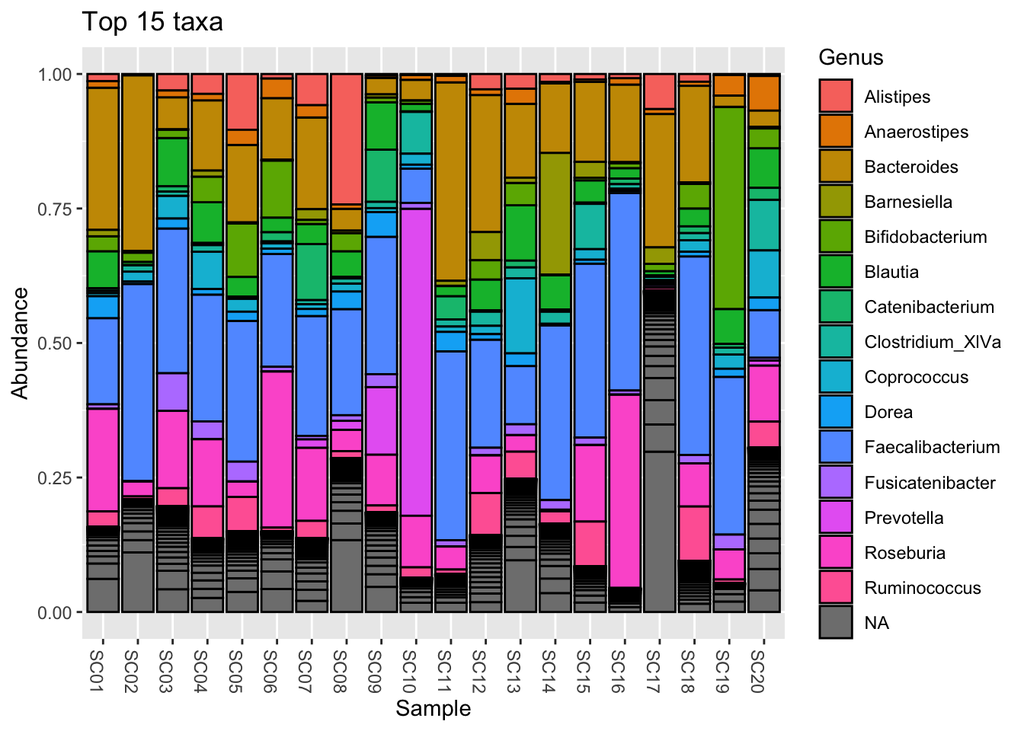

```r
# first, we agglomerate the data at the genus level
ps_genus <- tax_glom(ps, "Genus")

# select the top 15 genera
top15 <- names(sort(taxa_sums(ps_genus), decreasing=TRUE))[1:15]

# calculate relative abundances
ps_genus <- transform_sample_counts(ps_genus, function(ASV) ASV/sum(ASV))

# group everything that's not in the top 15 as NA and plot
tax_table(ps_genus)[!rownames(tax_table(ps_genus)) %in% top15,"Genus"] <- NA
plot_bar(ps_genus, fill="Genus", title = "Top 15 taxa")
```